# Nonparametric Statistics

July 20, 2018

## Linear Models

- Linear models have several specialized varients
  - Two-Sample T-test
  - Simple Regression
  - ANOVA - (Essentially a 2-sample t-test with more than two categories)
  - Multiple Regression - Several explanatory covariates (either categorical or continuous)
  - Mixed Effects Models
  - Generalized Additive Models (GAMs)

## T-tests

- In order for a t-test with equal variances to be appropriate, one of the following must be true:
  - The observed data is could reasonably be distributed \[Y_{ij} = \mu_i + \epsilon_{ij} \;\;\; \textrm{ where } \epsilon_{ij} \stackrel{iid}{\sim} N(0, \sigma)\]
  - The sample size is sufficiently large for the Central Limit Theorem to use that \(\bar{Y}_i \stackrel{.}{\sim} N\left( \mu_i, \frac{\sigma}{\sqrt{n}} \right)\)

## Linear Models in general

- Have several model assumptions
  - Independence of error terms
  - Constant variance of error terms
  - Normally distributed error terms
- "All models are wrong, but some are useful" - George Box
- Model assumptions must be *approximately* met for the results to be useful.

## Linear Models are robust (to some violations of assumptions)

- If the model assumptions aren't (approximately) met:
  - Non-Independence - BIG PROBLEM!
    - Addressed by modeling how the observations are related
    - Should be addressed in the study design, not *post-hoc*.
  - Non-Constant Variance - Problem!
    - Addressed by transforming the response variable
  - Non-Normality of Errors - Problem if insufficient sample size.
    - Addressed by transforming the response variable

## An Example

The ratio of DDE (related to DDT) to PCB concentrations in bird eggs has been shown to have had a number of biological implications. The ratio is used as an indication of the movement of contamination through the food chain.

## Data - Dotplots

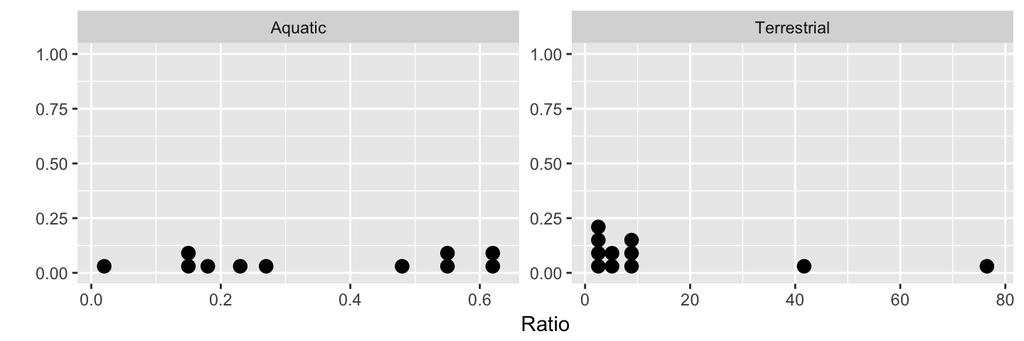

## Data - Boxplots

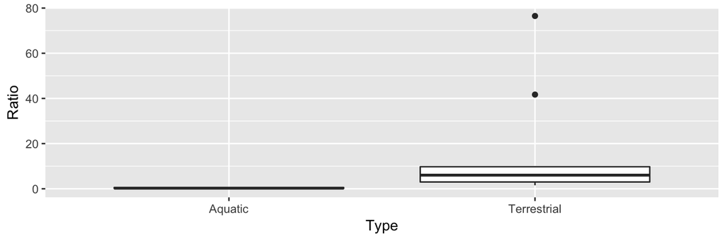

## Data

- Every single Aquatic observation is lower the the smallest Terrestrial.
- Obviously there significant difference between Aquatic and Terrestrial, but how should I quantify that difference statistically?
  - The sample size is pretty small, so maybe it is just random chance…
  - But the data, particularly for the Terrestrial data, is certainly not Normally distributed.

## Typical fix for model assumptions

- Non-Constant Variance or Non-Normality?
  - Transform the response variable \(Y\)
    - \(\log(Y)\)
    - \(\sqrt(Y)\)
    - *rank transformation*
    - *sign transformation*
  - These transformations are very commonly done!

## Log Transform the Data?

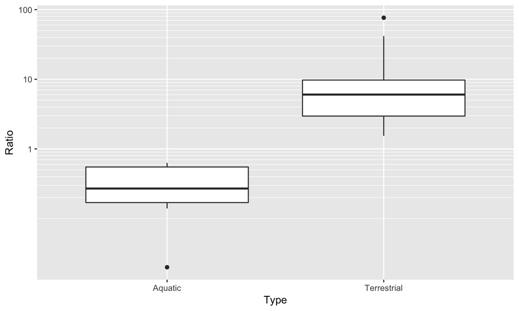

## Sign Transformations

- While the log-transformation is better, it still isn't great.
- But these are clearly different distributions.
- Lets just make the *sign* transformation where we pivot the Ratio values about \(y=1\). \[Y_i^* = \left\{ \begin{aligned} -1 & \textrm{ if } Y_i < 1 \\ +1 & \textrm{ if } Y_i \ge 1 \\ \end{aligned} \right.\] \[Y_i^* = \textrm{sign}(Y_i - 1)\]

## This feels sort-of like a Chi-Squared Test!

|  | -1 | +1 |
| --- | --- | --- |
| **Aquatic** | 11 | 0 |
| **Terrestial** | 0 | 11 |

## What would happen if the distributions were the same?

- We are building up the idea of the sampling distribution assuming
- \(H_0\): *No difference in distribution*
- If there were no difference between groups, then the -1 and 1 values would be equally spread between the two groups.

## I might have seen the following

|  | -1 | +1 |
| --- | --- | --- |
| **Aquatic** | 5 | 6 |
| **Terrestial** | 7 | 4 |

## Give the groups numerical labels as well!

|  | -1 | +1 |
| --- | --- | --- |
| **-1** | 11 | 0 |
| **+1** | 0 | 11 |

- Test statistic?
- Define \(G_i\) as the group number (-1 or 1)
- \[X = \sum_{i=1}^n G_i y_i^* = 22\]
- This is as large as the test statistic could possibly be.

## What does the sampling distribution look like?

- We need to figure out the distribution of the test statistic under the null hypothesis of no difference
- Should have the 11 Aquatic observations evenly distributed between above and below 1 classes.
- Likewise, should have the 11 Terrestrial observations evenly distributed between the above/below 1 classes.
- We could use probability theory to figure this out… but we are lazy.

## Data we start with

|  | Ratio | Type | Group | Sign |
| --- | --- | --- | --- | --- |
| **1** | 76.5 | Terrestrial | 1 | 1 |
| **2** | 6.03 | Terrestrial | 1 | 1 |
| **3** | 3.51 | Terrestrial | 1 | 1 |
| **20** | 0.16 | Aquatic | -1 | -1 |
| **21** | 0.18 | Aquatic | -1 | -1 |
| **22** | 0.02 | Aquatic | -1 | -1 |

## Shuffle the Sign Values

```r
PollutionRatios %>%
  mutate( Sign.Sim = mosaic::shuffle(Sign) ) %>%
  FSA::headtail()
```

```
##    Ratio        Type Group Sign Sign.Sim
## 1  76.50 Terrestrial     1    1        1
## 2   6.03 Terrestrial     1    1       -1
## 3   3.51 Terrestrial     1    1       -1
## 20  0.16     Aquatic    -1   -1        1
## 21  0.18     Aquatic    -1   -1        1
## 22  0.02     Aquatic    -1   -1       -1
```

## Multiply Group * Sign.Sim

```r
PollutionRatios %>%
  mutate( Sign.Sim = mosaic::shuffle(Sign) ) %>%
  mutate( output = Group * Sign.Sim ) %>%
  FSA::headtail()
```

```
##    Ratio        Type Group Sign Sign.Sim output
## 1  76.50 Terrestrial     1    1        1      1
## 2   6.03 Terrestrial     1    1       -1     -1
## 3   3.51 Terrestrial     1    1        1      1
## 20  0.16     Aquatic    -1   -1        1     -1
## 21  0.18     Aquatic    -1   -1       -1      1
## 22  0.02     Aquatic    -1   -1       -1      1
```

## Then sum the output column

```r
PollutionRatios %>%
  mutate( Sign.Sim = mosaic::shuffle(Sign) ) %>%
  mutate( output = Group * Sign.Sim ) %>%
  summarise( X = sum( output ) )
```

```
##   X
## 1 2
```

## Do this MANY MANY times

```r
SamplingDist <- mosaic::do(10000) *
  PollutionRatios %>%
    mutate( Sign.Sim = mosaic::shuffle(Sign) ) %>%
    mutate( output = Group * Sign.Sim ) %>%
    summarise( X = sum( output ) )
```

## The output distribution

```
##        X
## 1      2
## 2     -2
## 3      2
## 9998  -6
## 9999  -6
## 10000  2
```

## The output distribution

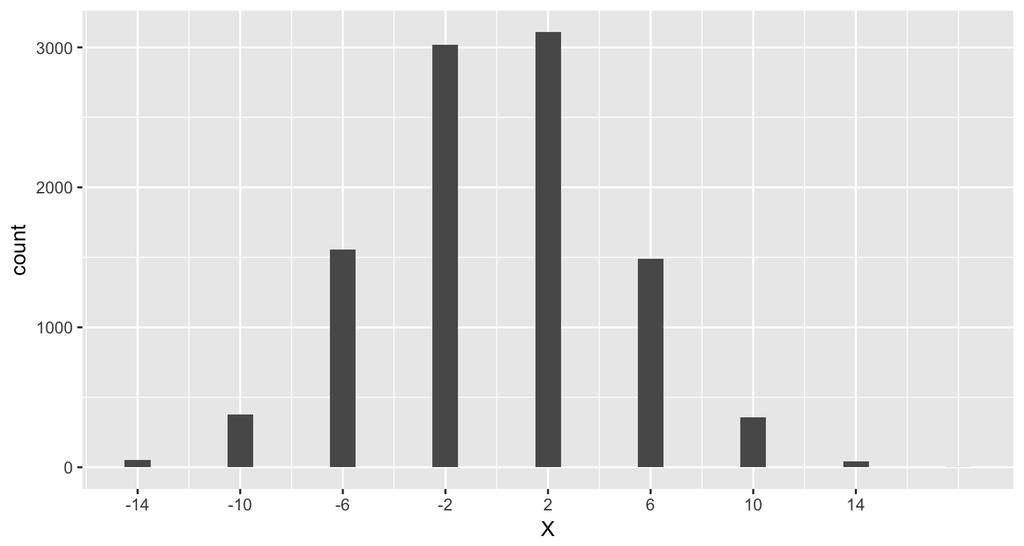

## The p-value

- Recall a p-value is *"the probability of seeing your data, or something more extreme, given the null hypothesis is true."*
- Because we saw NO simulations out of 10,000 that were as or more extreme, we can approximate the p-value as less than 1 in 10,000.

## Sign Transformation Summary

- The *sign* transformation takes a quantitative variable and turns it into a categorical variable with just two levels.
- If the resulting data is amenable, we could then do a traditional categorical analysis, but often simulating the sampling distribution is just as easy.
- But in reducing a quantitative variable to just two classes, we've lost a *huge* amount of information.
- Is there an intermediate transformation?

## Rank Transformation

- Sort all of the data, smallest-to-largest, and call the order number the *rank*.
- Smallest value has rank 1, second smallest has rank 2, etc, until the largest value has rank \(n\).
- If there are ties, give an average rank.

## Example: Camouflage Tent Material

The military was testing if a green patterned camouflage material for tents was more effective than a solid plain green material. Data below is the average distance an observer was away from a particular tent when it was first observed.

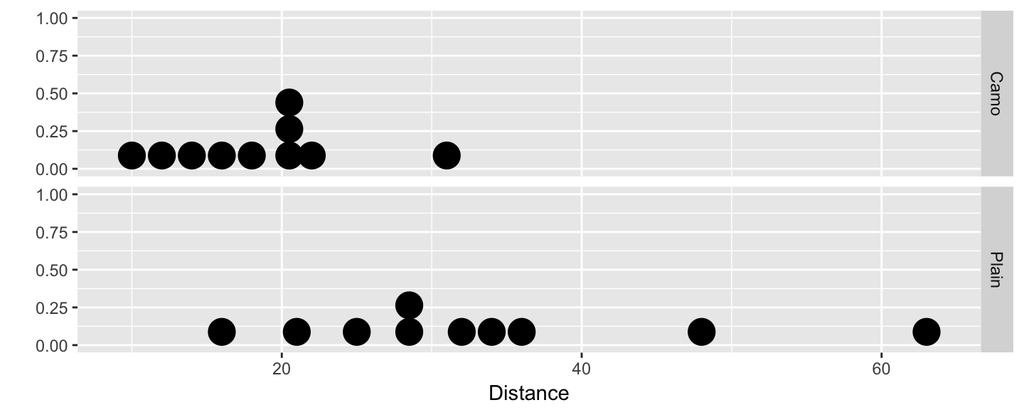

## Example: Camouflage Tent Material

| Distance | Type | Rank |
| --- | --- | --- |
| 10 | Camo | 1 |
| 12 | Camo | 2 |
| 14 | Camo | 3 |
| 16 | Camo | 4.5 |
| 16 | Plain | 4.5 |
| 18 | Camo | 6 |
| 20 | Camo | 7.5 |
| 20 | Camo | 7.5 |

## Now what?

We have two options:

## Standard T-test on the ranks

```
##
##  Welch Two Sample t-test
##
## data:  Rank by Type
## t = -3.7247, df = 17.849, p-value = 0.00157
## alternative hypothesis: true difference in means is not equal to 0
## 95 percent confidence interval:
##  -11.88938  -3.31062
## sample estimates:
##  mean in group Camo mean in group Plain
##                 6.7                14.3
```

## Wilcoxen Rank Sum

- Let
  - \(n_i\) be the number of observations in group \(i\)
  - \(R_{ij}\) the the rank of the \(j\)th observation in group \(i\)
  - \(n = \sum n_i\)
- For each group, calculate the sum of the ranks \[R_i = \sum_{j=1}^{n_i} R_{ij}\]

## Wilcoxen Rank Sum

- Note, for two groups: \(R_1 + R_2 = n(n+1)/2\)
- Under the null hypotheses, \[R_1 \approx R_2 \approx \frac{n(n+1)}{4}\]
- Let \(W = R_1 - R_2\)

## Wilcoxen Rank Sum

```r
  Tents %>%
    group_by(Type) %>%
    summarise( R = sum( Rank ) )
```

```
## # A tibble: 2 x 2
##   Type      R
##   <fct> <dbl>
## 1 Camo     67
## 2 Plain   143
```

## Wilcoxen Rank Sum

```r
  Tents %>%
    group_by(Type) %>%
    summarise( R = sum( Rank ) ) %>%
    summarise( W=diff(R) )
```

```
## # A tibble: 1 x 1
##       W
##   <dbl>
## 1    76
```

## Simulating the Sampling Distribution under \(H_0\)

```r
SamplingDist <- mosaic::do(10000) *
  Tents %>%
    mutate( Rank.Sim = mosaic::shuffle(Rank) ) %>%
    group_by(Type) %>%
    summarise( R = sum( Rank.Sim ) ) %>%
    summarise( W=diff(R) )
```

## Simulating the Sampling Distribution under \(H_0\)

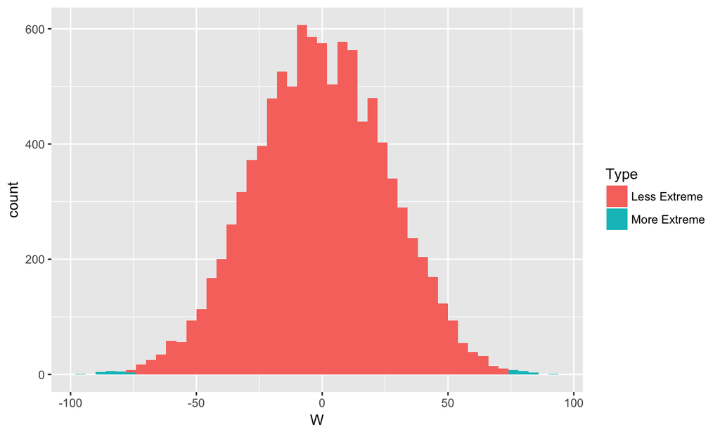

## Calculating an estimated p-value

```r
SamplingDist %>%
  summarize( p.value = mosaic::prop( abs(W) >= 76 ) )
```

```
##   p.value
## 1  0.0037
```

## Mann-Whitney U-Statistic

Another choice for a test statistic, which is traditionally used is: \[U_i = R_i - \frac{n_i(n_i + 1)}{2}\] \[U = \min (U_1, U_2)\]

## Considerations

- Nonpparametric tests are more widely applicable than a standard t-test.
- By using rank or sign transformed responses, we cannot make confidence intervals on the scale that is scientifically useful.
- If the usual requirements are met for a t-test, then the standard approach is more powerful and should preferentially be used.

## Simulation Study: Goals to Assertain

- Question 1: If \(H_0\) is true, does an \(\alpha\)-level test reject the null hypothesis \(\alpha\)% of the time.
- Question 2: If \(H_0\) is false, which test procedure rejects \(H_0\) more frequently? The probability of rejecting \(H_0\) is referred to as *power*.

## Distributions to sample from

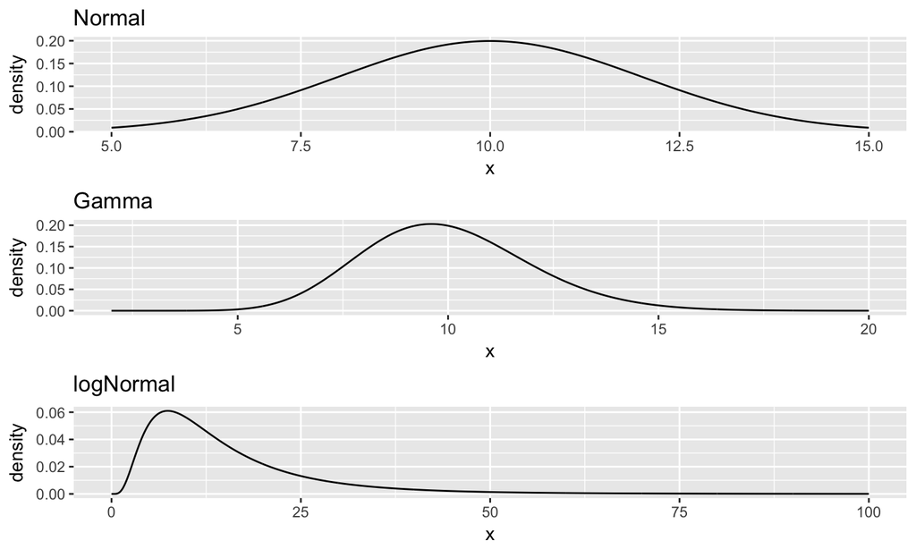

## What if the data was Normally distributed?

## Normal Data - Type I Error Rate

- If \(H_0\) is true, we should reject \(H_0\) at some specified rate. Usually 0.05.
- Generate 10000 datasets where \(H_0\) is true, and perform each analysis.
- Observe the proportion of datasets that result in a p-value less than 0.05.
- Give a 95% Confidence Interval for the Type I Error rate, too.
- If Type I Error Rate is too big, that is BAD.

## Normal Data - Type I Error Rate

| method | Est | lwr | upr |
| --- | --- | --- | --- |
| t-test | 0.0469 | 0.043 | 0.051 |
| Rank Tranformed t-test | 0.0495 | 0.045 | 0.054 |
| Mann-Whitney | 0.0409 | 0.037 | 0.045 |

## Normal Data - Power

- Generate many datasets where the null hypothesis is false and the difference in means is not zero.
- The percentage of datasets that result in a statistically significant difference is the *power*.
- As the means of the two populations get farther apart (\(\delta\)), the power, probability of rejecting \(H_0\), should get larger.
- The larger the probability or rejection, the better!

## Normal Data - Power

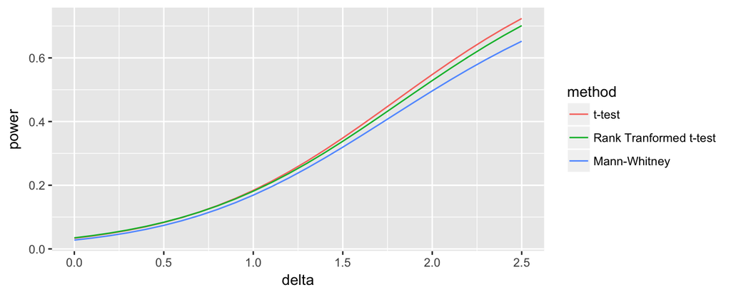

## Gamma distributed data - Type I Error Rate

| method | Est | lwr | upr |
| --- | --- | --- | --- |
| t-test | 0.046 | 0.042 | 0.051 |
| Rank Tranformed t-test | 0.053 | 0.049 | 0.057 |
| Mann-Whitney | 0.043 | 0.039 | 0.047 |

## Gamma Distribution - Power

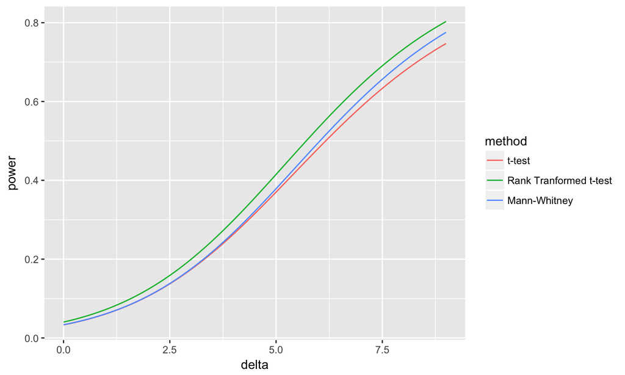

## LogNormal distributed data - Type I Error Rates

| method | Est | lwr | upr |
| --- | --- | --- | --- |
| t-test | 0.018 | 0.011 | 0.029 |
| Rank Tranformed t-test | 0.051 | 0.039 | 0.067 |
| Mann-Whitney | 0.043 | 0.032 | 0.058 |

## LogNormal distributed data - power

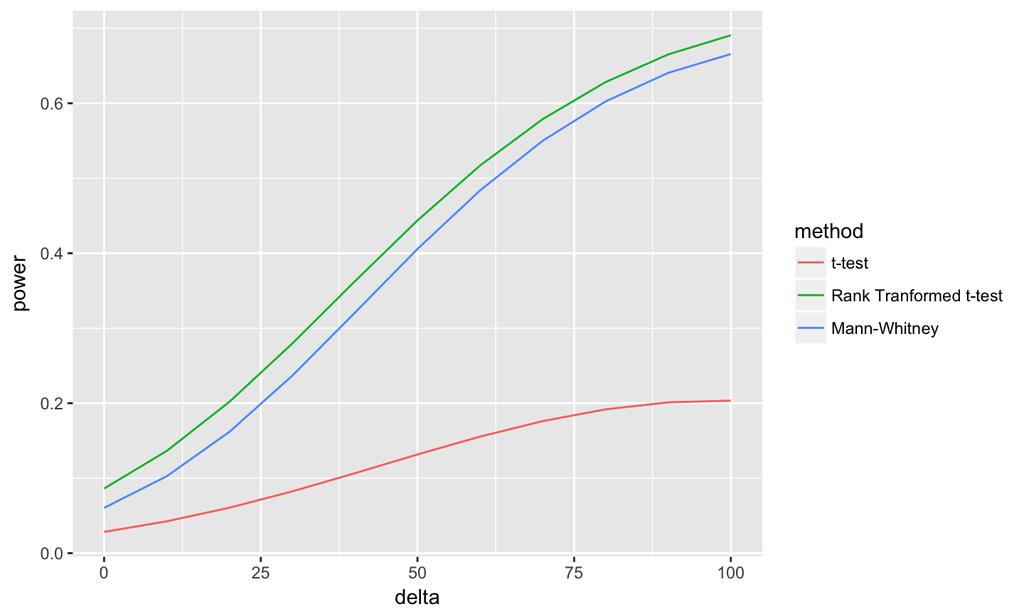